# R Notebook

# create histogram to see the number of patients with liver disease

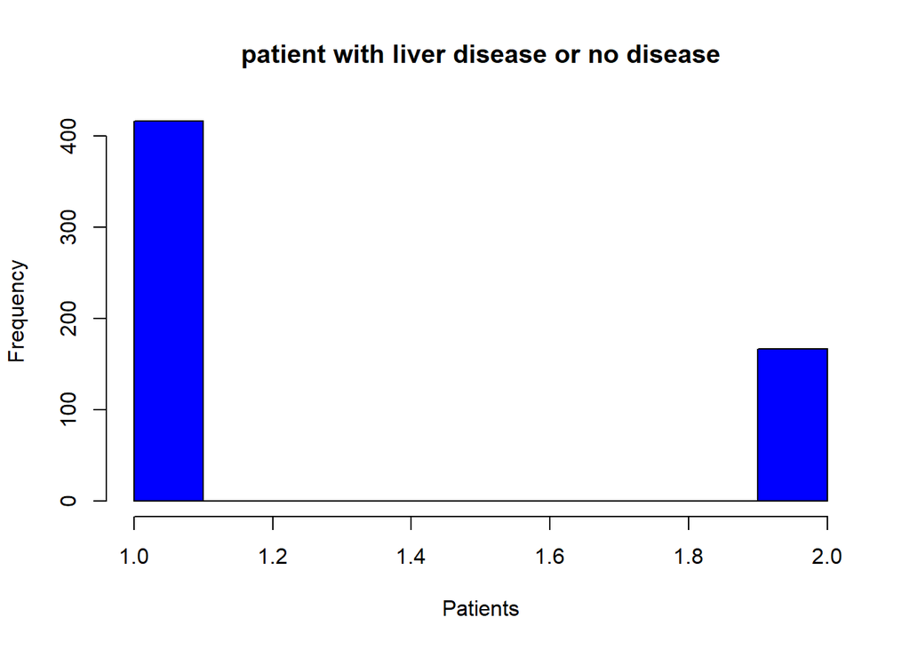

```r
hist(dataset$Dataset,
     col  = "blue",
     xlab = "Patients",
     ylab = "Frequency",
     main = "patient with liver disease or no disease")
```

```r
prdataset = read.csv("C:\\Users\\User\\Desktop\\dataMining\\proccesseddataset (1).csv")
```

# Data Mining Technique

in classification:

1. Decision Trees:

Methods Used: Information Gain, Gain Ratio, Gini Index

R Packages: rpart, rpart.plot

Reasoning: Decision trees are used for predictive modeling and understanding variable interactions. We applied different splitting criteria (information gain, gain ratio, Gini index) to build decision trees and predict the outcome of liver disease based on various attributes. We evaluated model performance using metrics like accuracy, sensitivity, specificity, precision, recall, and confusion matrices.

2. Holdout Method for Training and Testing Sets:

R Packages: caret, caTools

Reasoning: The holdout method involves splitting the dataset into separate training and testing sets, typically by reserving a certain portion for training and the rest for testing. This technique allows the model to be trained on one set of data and evaluated on a completely independent set.

other R Packages we used it:(RWeka, C50, e1071, boot) each package serves specific purposes within the of machine learning, statistical analysis, and resampling techniques, providing tools and implementations for various algorithms and methodologies.

The goal is to develop an accurate model for classifying new patients into disease categories(1 diseases or 2 no diseases ).

in clustring:

Methods Used: K-Means Clustering:

R Packages: stats, fpc, factoextra

Reasoning: K-Means clustering is an unsupervised learning technique used to group similar instances together based on their features. We applied K-Means with varying values of k (number of clusters) to Identify hidden patterns or groupings within the patient data related to liver disease. We evaluated clustering performance using metrics like Average Silhouette Width, Within-Cluster Sum of Squares, BCubed Precision, and BCubed Recall.

# classification

we will be use holdout method

```r
library(RWeka)
library(caret)
library(e1071)
library(C50)
library(boot)
library(caTools)
library(rpart)
```

```r
library(rpart.plot)
# Set the seed for reproducibility
set.seed(123)
```

# size for training 70% using holdout method

tree of information gain: (best tree)

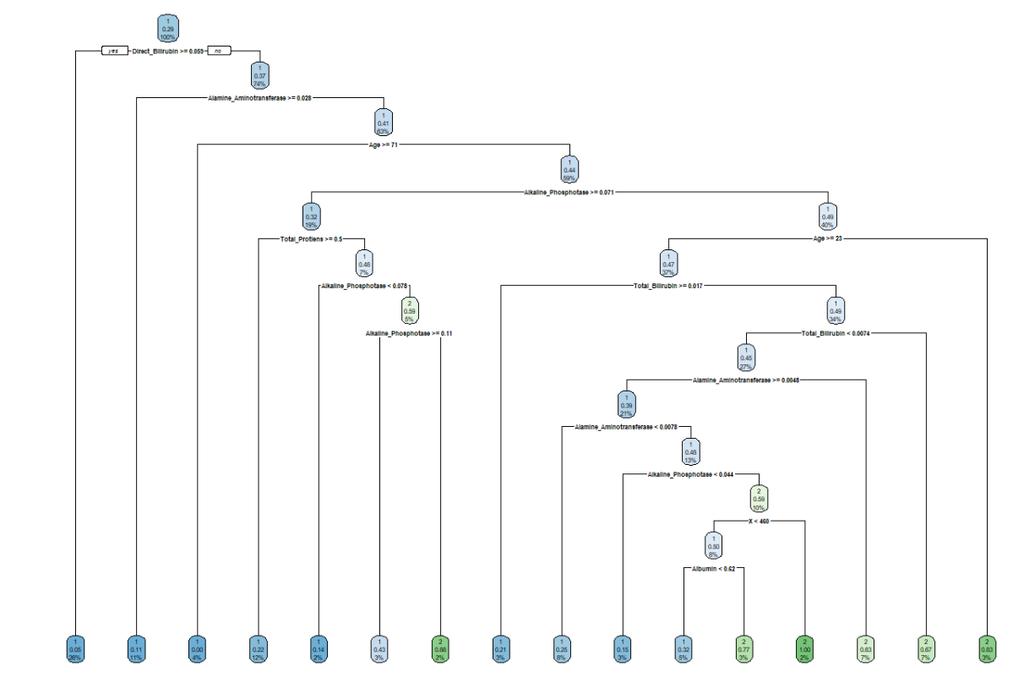

tree of gain ratio:

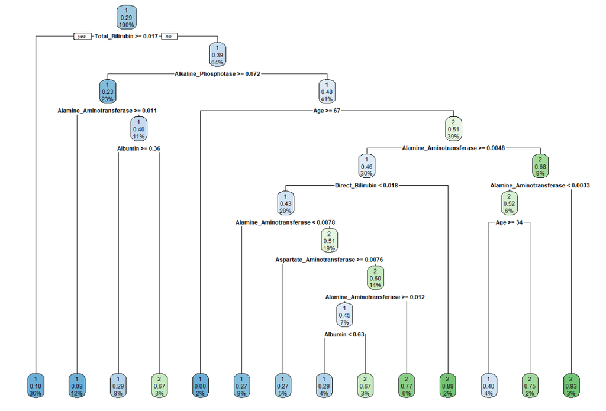

tree of Gini index:

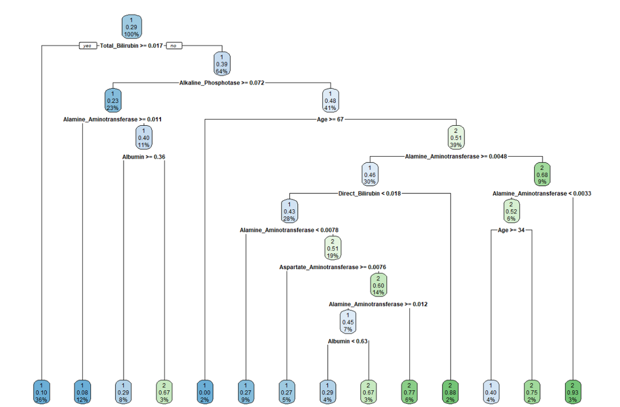

```r
# Subset the first dataset
df1 <- prdataset[which(prdataset$Dataset == 1),]

# Subset the second dataset
df2 <- prdataset[which(prdataset$Dataset == 2),]

# Splitting the first dataset
n1 <- nrow(df1)  # Total number of rows in df1
train_indices1 <- sample(1:n1, 0.7 * n1, replace = FALSE)  # Randomly select 70% of indices for training
test_indices1 <- setdiff(1:n1, train_indices1)  # Remaining indices for testing

# Splitting the second dataset
n2 <- nrow(df2)  # Total number of rows in df2
train_indices2 <- sample(1:n2, 0.7 * n2, replace = FALSE)  # Randomly select 70% of indices for training
test_indices2 <- setdiff(1:n2, train_indices2)  # Remaining indices for testing

# Creating the training and testing sets
train_df1 <- df1[train_indices1, ]
test_df1 <- df1[test_indices1, ]
train_df2 <- df2[train_indices2, ]
test_df2 <- df2[test_indices2, ]

# Combining the 70% training sets
combined_train <- rbind(train_df1, train_df2)

# Combining the 30% testing sets
combined_test <- rbind(test_df1, test_df2)
```

## Build the decision tree using information gain

```r
decision_tree <- rpart(Dataset ~ ., data = combined_train, method = "class", parms = list(split = "information"))
```

### Plot the decision tree

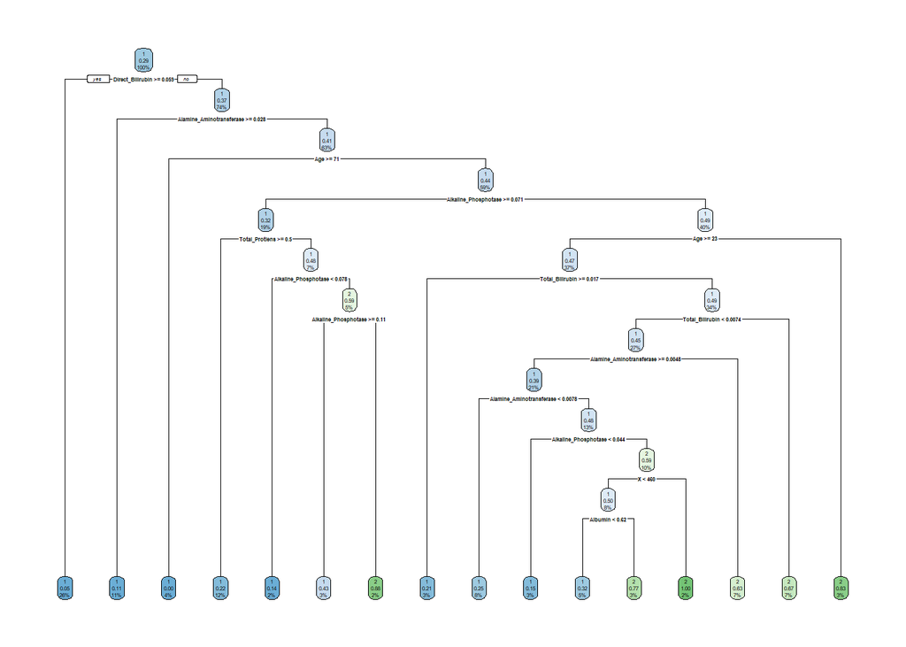

```r
rpart.plot(decision_tree)
```

the root node of interest in this data is “Direct_Bilirubin.” This means that the decision tree starts by splitting the data based on the value of the “Direct_Bilirubin” feature.

The decision tree then branches out to other internal nodes, such as “Alamine_Aminotransferase,” “Age,” “Alkaline_Phosphotase,” “Total_Bilirubin,” “Albumin,” and “Total_Protiens.”

### Make predictions on the testing set

```r
predictions <- predict(decision_tree, newdata = combined_test, type = "class")
```

### Compare the predictions with the actual values

```r
table(predictions, combined_test$Dataset)
```

```
##
## predictions   1   2
##           1 106  36
##           2  19  15
```

```r
predictions <- factor(predictions, levels = c("1", "2"))
combined_test$Dataset <- factor(combined_test$Dataset, levels = c("1", "2"))

confusionMatrix(predictions, combined_test$Dataset)
```

```
## Confusion Matrix and Statistics
##
##           Reference
## Prediction   1   2
##          1 106  36
##          2  19  15
##
##                Accuracy : 0.6875
##                  95% CI : (0.6134, 0.7551)
##     No Information Rate : 0.7102
##     P-Value [Acc > NIR] : 0.77420
##
##                   Kappa : 0.1577
##
##  Mcnemar's Test P-Value : 0.03097
##
##             Sensitivity : 0.8480
##             Specificity : 0.2941
##          Pos Pred Value : 0.7465
##          Neg Pred Value : 0.4412
##              Prevalence : 0.7102
##          Detection Rate : 0.6023
##    Detection Prevalence : 0.8068
##       Balanced Accuracy : 0.5711
##
##        'Positive' Class : 1
##
```

Accuracy (0.6875): The model’s predictions are correct approximately 68.75% of the time.

Precision (0.7465): About 74.65% of the instances predicted as positive are actually positive.

Sensitivity (0.8480): The model correctly identifies about 84.80% of the actual positive instances.

Specificity (0.2941): The model correctly identifies only about 29.41% of the actual negative instances.

the model demonstrates a relatively high sensitivity, indicating its effectiveness in detecting positive instances. However, it has limitations in accurately identifying negative instances, as shown by the low specificity. The precision indicates that the model is reasonably good at predicting positive instances, with a precision of 74.65%.

## Build the decision tree using gain ratio

```r
decision_tree <- rpart(Dataset ~ ., data = combined_train, method = "class", parms = list(split = "gain"))
```

### Plot the decision tree

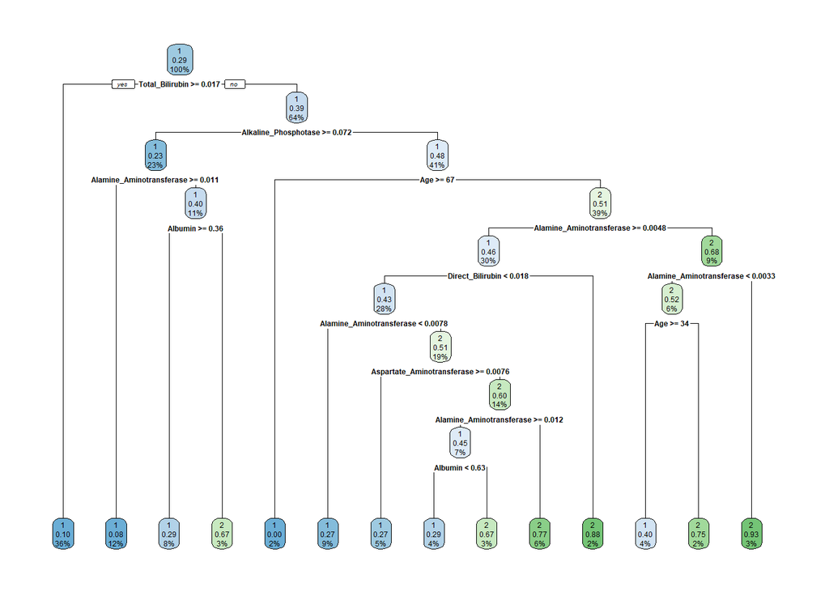

```r
rpart.plot(decision_tree)
```

the root node of interest in this data is “Total_Bilirubin.” This means that the decision tree starts by splitting the data based on the value of the “Total_Bilirubin” feature.

The decision tree then branches out to other internal nodes, such as “Alkaline_Phosphotase,” “Alamine_Aminotransferase,” “Albumin,” “Age,” .

### Make predictions on the testing set

```r
predictions <- predict(decision_tree, newdata = combined_test, type = "class")
```

### Compare the predictions with the actual values

```r
table(predictions, combined_test$Dataset)
```

```
##
## predictions   1   2
##           1 106  36
##           2  19  15
```

```r
predictions <- factor(predictions, levels = c("1", "2"))
combined_test$Dataset <- factor(combined_test$Dataset, levels = c("1", "2"))

confusionMatrix(predictions, combined_test$Dataset)
```

```
## Confusion Matrix and Statistics
##
##           Reference
## Prediction   1   2
##          1 106  36
##          2  19  15
##
##                Accuracy : 0.6875
##                  95% CI : (0.6134, 0.7551)
##     No Information Rate : 0.7102
##     P-Value [Acc > NIR] : 0.77420
##
##                   Kappa : 0.1577
##
##  Mcnemar's Test P-Value : 0.03097
##
##             Sensitivity : 0.8480
##             Specificity : 0.2941
##          Pos Pred Value : 0.7465
##          Neg Pred Value : 0.4412
##              Prevalence : 0.7102
##          Detection Rate : 0.6023
##    Detection Prevalence : 0.8068
##       Balanced Accuracy : 0.5711
##
##        'Positive' Class : 1
##
```

Accuracy (0.6875): The model’s predictions are correct approximately 68.75% of the time.

Precision (0.7465): About 74.65% of the instances predicted as positive are actually positive.

Sensitivity (0.8480): The model correctly identifies about 84.80% of the actual positive instances.

Specificity (0.2941): The model correctly identifies only about 29.41% of the actual negative instances.

the model demonstrates a relatively high sensitivity, indicating its effectiveness in detecting positive instances. However, it has limitations in accurately identifying negative instances, as shown by the low specificity. The precision indicates that the model is reasonably good at predicting positive instances, with a precision of 74.65%.

## Build the decision tree using the Gini index

```r
decision_tree <- rpart(Dataset ~ ., data = combined_train, method = "class")
```

### Plot the decision tree

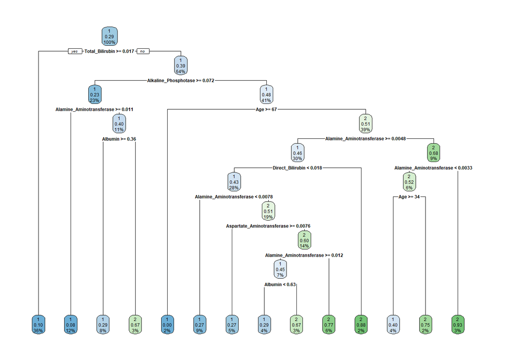

```r
rpart.plot(decision_tree)
```

the root node of interest in this data is “Total_Bilirubin.” This means that the decision tree starts by splitting the data based on the value of the “Total_Bilirubin” feature.

The decision tree then branches out to other internal nodes, such as “Alkaline_Phosphotase,” “Alamine_Aminotransferase,” “Albumin,” “Age”.

### Make predictions on the testing set

```r
predictions <- predict(decision_tree, newdata = combined_test, type = "class")
```

### Compare the predictions with the actual values

```r
table(predictions, combined_test$Dataset)
```

```
##
## predictions   1   2
##           1 106  36
##           2  19  15
```

```r
predictions <- factor(predictions, levels = c("1", "2"))
combined_test$Dataset <- factor(combined_test$Dataset, levels = c("1", "2"))

confusionMatrix(predictions, combined_test$Dataset)
```

```
## Confusion Matrix and Statistics
##
##           Reference
## Prediction   1   2
##          1 106  36
##          2  19  15
##
##                Accuracy : 0.6875
##                  95% CI : (0.6134, 0.7551)
##     No Information Rate : 0.7102
##     P-Value [Acc > NIR] : 0.77420
##
##                   Kappa : 0.1577
##
##  Mcnemar's Test P-Value : 0.03097
##
##             Sensitivity : 0.8480
##             Specificity : 0.2941
##          Pos Pred Value : 0.7465
##          Neg Pred Value : 0.4412
##              Prevalence : 0.7102
##          Detection Rate : 0.6023
##    Detection Prevalence : 0.8068
##       Balanced Accuracy : 0.5711
##
##        'Positive' Class : 1
##
```

Accuracy (0.6875): The model’s predictions are correct approximately 68.75% of the time.

Precision (0.7465): About 74.65% of the instances predicted as positive are actually positive.

Sensitivity (0.8480): The model correctly identifies about 84.80% of the actual positive instances.

Specificity (0.2941): The model correctly identifies only about 29.41% of the actual negative instances.

the model demonstrates a relatively high sensitivity, indicating its effectiveness in detecting positive instances. However, it has limitations in accurately identifying negative instances, as shown by the low specificity. The precision indicates that the model is reasonably good at predicting positive instances, with a precision of 74.65%.

## What is the best tree for this size ?

All decision trees have identical performance. The metrics, including accuracy, precision, sensitivity, and specificity, are exactly the same for both trees.

Given that the performance metrics are identical, the decision between the two trees can be based on interpretability. In this case, the Information Gain tree may be preferred because it has more branches, providing more detailed information

# size for training 60%:

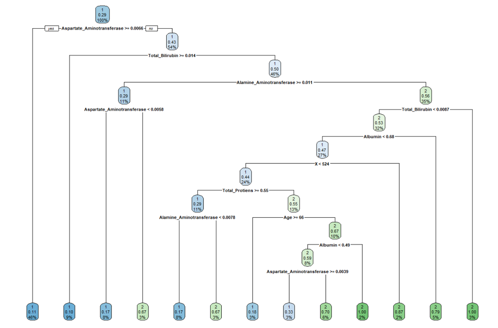

tree of gain ration:

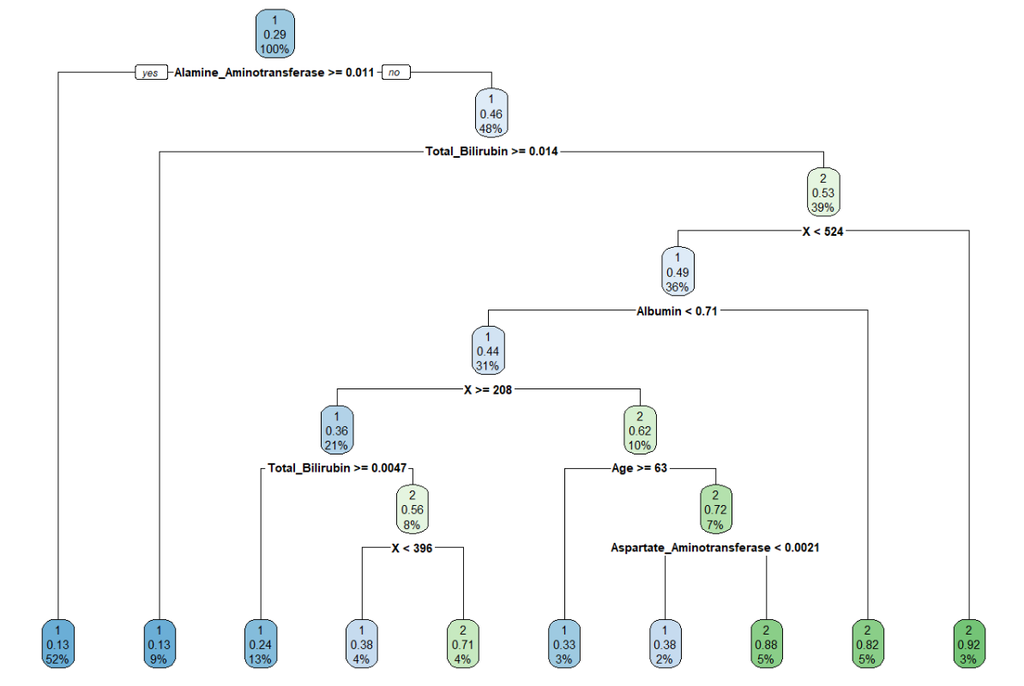

tree of gini index:

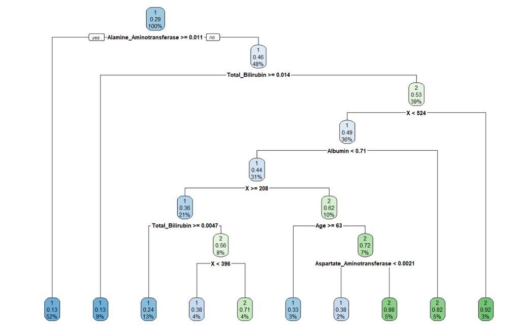

```r
#Set the seed for reproducibility 60%
set.seed(123)
```

## Split the dataset into training and testing sets

```r
# Subset the first dataset
df1 <- prdataset[which(prdataset$Dataset == 1),]

# Subset the second dataset
df2 <- prdataset[which(prdataset$Dataset == 2),]

# Splitting the first dataset
n1 <- nrow(df1)  # Total number of rows in df1
train_indices1 <- sample(1:n1, 0.6 * n1, replace = FALSE)  # Randomly select 70% of indices for training
test_indices1 <- setdiff(1:n1, train_indices1)  # Remaining indices for testing

# Splitting the second dataset
n2 <- nrow(df2)  # Total number of rows in df2
train_indices2 <- sample(1:n2, 0.6 * n2, replace = FALSE)  # Randomly select 70% of indices for training
test_indices2 <- setdiff(1:n2, train_indices2)  # Remaining indices for testing

# Creating the training and testing sets
train_df1 <- df1[train_indices1, ]
test_df1 <- df1[test_indices1, ]
train_df2 <- df2[train_indices2, ]
test_df2 <- df2[test_indices2, ]

# Combining the 60% training sets
combined_train <- rbind(train_df1, train_df2)

# Combining the 40% testing sets
combined_test <- rbind(test_df1, test_df2)
```

## Build the decision tree using information gain

```r
decision_tree <- rpart(Dataset ~ ., data = combined_train, method = "class", parms = list(split = "information"))
```

### Plot the decision tree

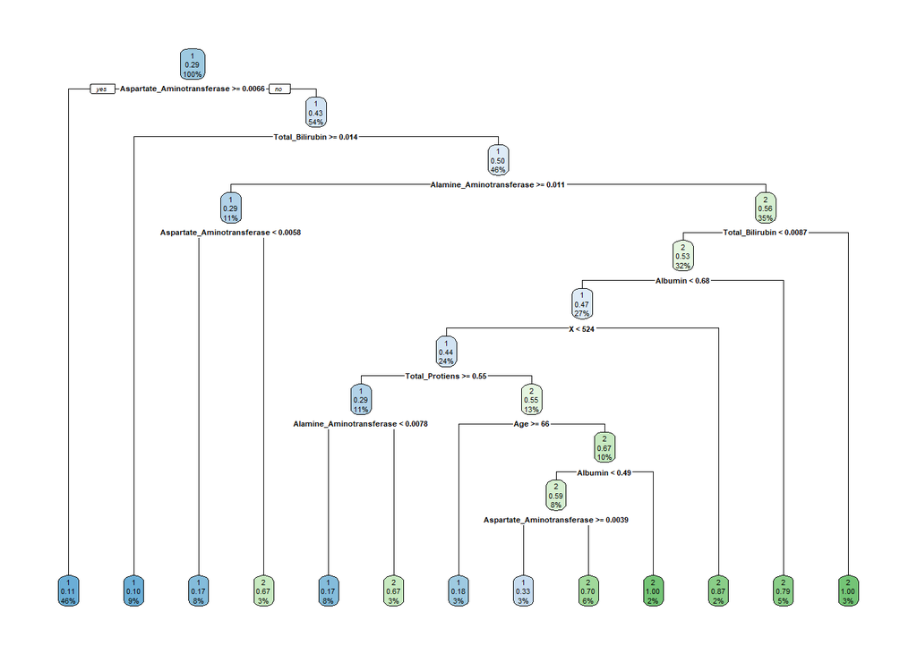

```r
rpart.plot(decision_tree)
```

the root node of interest in this data is “Aspartate_Aminotransferase.” This means that the decision tree starts by splitting the data based on the value of the “Aspartate_Aminotransferase” feature.

The decision tree then branches out to other internal nodes, such as “Total_Bilirubin,” “Alamine_Aminotransferase,” “Age,” and “Albumin,”

### Make predictions on the testing set

```r
predictions <- predict(decision_tree, newdata = combined_test, type = "class")
```

```r
table(predictions, combined_test$Dataset)
```

```
##
## predictions   1   2
##           1 133  47
##           2  34  20
```

```r
predictions <- factor(predictions, levels = c("1", "2"))
combined_test$Dataset <- factor(combined_test$Dataset, levels = c("1", "2"))

confusionMatrix(predictions, combined_test$Dataset)
```

```
## Confusion Matrix and Statistics
##
##           Reference
## Prediction   1   2
##          1 133  47
##          2  34  20
##
##                Accuracy : 0.6538
##                  95% CI : (0.5891, 0.7146)
##     No Information Rate : 0.7137
##     P-Value [Acc > NIR] : 0.9806
##
##                   Kappa : 0.1008
##
##  Mcnemar's Test P-Value : 0.1824
##
##             Sensitivity : 0.7964
##             Specificity : 0.2985
##          Pos Pred Value : 0.7389
##          Neg Pred Value : 0.3704
##              Prevalence : 0.7137
##          Detection Rate : 0.5684
##    Detection Prevalence : 0.7692
##       Balanced Accuracy : 0.5475
##
##        'Positive' Class : 1
##
```

Accuracy (0.6538): The model’s predictions are correct approximately 65.38% of the time.

Precision (0.7389): About 73.89% of the instances predicted as positive are actually positive.

Sensitivity (0.7964): The model correctly identifies about 79.64% of the actual positive instances.

Specificity (0.2985): The model correctly identifies only about 29.85% of the actual negative instances.

the model demonstrates a relatively high sensitivity, indicating its effectiveness in detecting positive instances. However, it has limitations in accurately identifying negative instances, as shown by the low specificity. The precision indicates that the model is reasonably good at predicting positive instances, with a precision of 73.89%.

## Build the decision tree using gain ratio

```r
decision_tree <- rpart(Dataset ~ ., data = combined_train, method = "class", parms = list(split = "gain"))
```

### Plot the decision tree

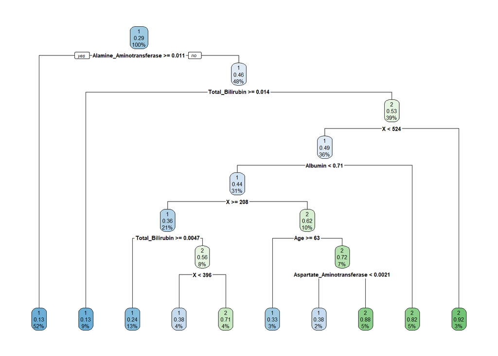

```r
rpart.plot(decision_tree)
```

the root node of interest in this data is “Alamine_Aminotransferase.” This means that the decision tree starts by splitting the data based on the value of the “Alamine_Aminotransferase” feature.

The decision tree then branches out to other internal nodes, such as “Age,” ,“Albumin” and “Total_Bilirubin.”

### Make predictions on the testing set

```r
predictions <- predict(decision_tree, newdata = combined_test, type = "class")
```

```r
table(predictions, combined_test$Dataset)
```

```
##
## predictions   1   2
##           1 151  54
##           2  16  13
```

```r
predictions <- factor(predictions, levels = c("1", "2"))
combined_test$Dataset <- factor(combined_test$Dataset, levels = c("1", "2"))

confusionMatrix(predictions, combined_test$Dataset)
```

```
## Confusion Matrix and Statistics
##
##           Reference
## Prediction   1   2
##          1 151  54
##          2  16  13
##
##                Accuracy : 0.7009
##                  95% CI : (0.6378, 0.7588)
##     No Information Rate : 0.7137
##     P-Value [Acc > NIR] : 0.6963
##
##                   Kappa : 0.1183
##
##  Mcnemar's Test P-Value : 9.764e-06
##
##             Sensitivity : 0.9042
##             Specificity : 0.1940
##          Pos Pred Value : 0.7366
##          Neg Pred Value : 0.4483
##              Prevalence : 0.7137
##          Detection Rate : 0.6453
##    Detection Prevalence : 0.8761
##       Balanced Accuracy : 0.5491
##
##        'Positive' Class : 1
##
```

Accuracy (0.7009): The model’s predictions are correct approximately 70.09% of the time.

Precision (0.7366): About 73.66% of the instances predicted as positive are actually positive.

Sensitivity (0.9042): The model correctly identifies about 90.42% of the actual positive instances.

Specificity (0.1940): The model correctly identifies only about 19.40% of the actual negative instances.

the model demonstrates a high sensitivity, indicating its effectiveness in detecting positive instances. However, it has limitations in accurately identifying negative instances, as shown by the low specificity. The precision indicates that the model is reasonably good at predicting positive instances, with a precision of 73.66%.